# The NOAA Fisheries Toolbox Survey

The NMFS National Modeling team  
03/19/2019

### Presentation outline

- Background on the survey
- Identifying key classes/features of stock assessment models to invest in
- Choosing tools for the toolbox
- How do we meet the needs of developers and users?

## Background

### Responses

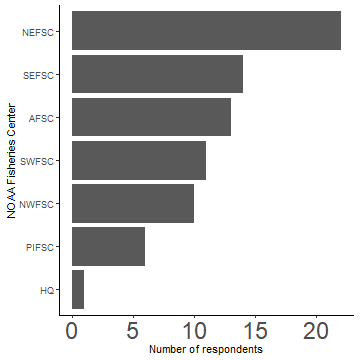

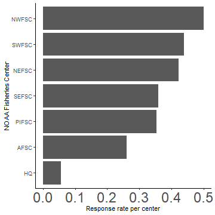

## Why is this work important?

- 87% of respondents use common tools for stock assessment
- 51% of respondents identified barriers to using tools
- All tool developers would benefit from more support

## Identifying key classes/features to invest in

### Classes of stock assessment models

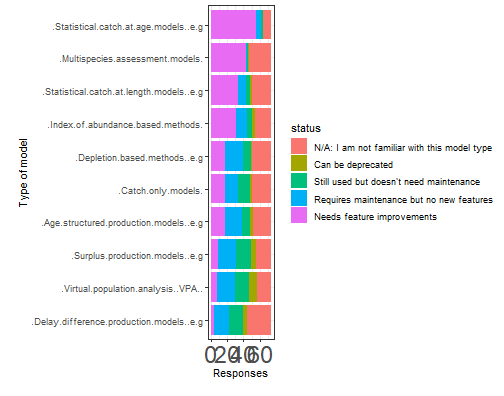

### New research investments

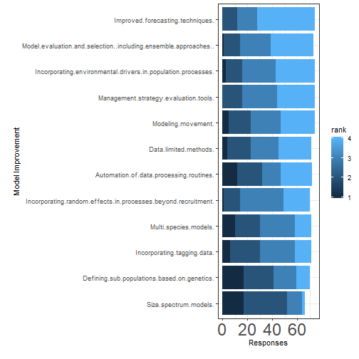

### Take-aways

- Statistical catch-at-age models
- Multispecies assessment models
- Improved forecasting techniques, model selection and ensembles
- Tools and models will continue to evolve

## Choosing tools for the Toolbox

### How do we prioritize models in the toolbox?

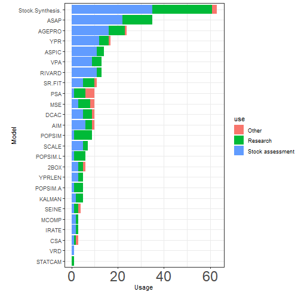

### Evidence for developing & onboarding new models

- Bayesian Surplus Production models (BSP, JABBA)
- Spatio-temporal models (VAST)
- Ensemble modeling tools (FLR)
- MSE tools
- TMB assessment models
- Translation tools

### Viewing and interacting with code

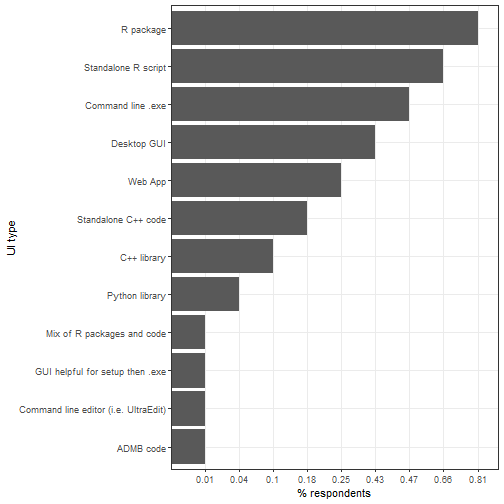

### Take-aways

- Prioritization of existing tools
- New tools to onboard or develop
- Existing/new R interfaces in one place
- Desire to view and customize code

## Structuring the toolbox to support developers and users

### User preferences

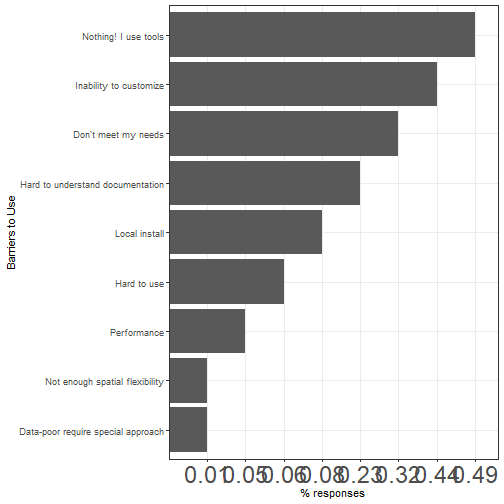

### What do tool developers need?

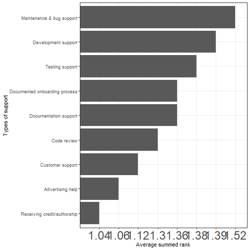

### Conclusions

- Lots of potential and need for unified modetling efforts
- Many existing tools/research topics not in current toolbox
- Opportunities to simplify for both tool developers and users by unifying standards and frameworks